# Regression analysis

Alexey Machikhin

5/23/2022

#### Загрузка итогового датасета

```r
library(readr)
library(car)
library(sjPlot)
library(MASS)
library(olsrr)
library(sjmisc)
library(ggpubr)
library(fitdistrplus)
library(cowplot)
```

```r
df = read_csv("data/ff14.csv")
```

#### Сравнение моделей. Отбор мотиваторов на основе критерия Фишера

```r
df$FF_freq = as.factor(df$FF_freq)
table(df$FF_freq)
```

```
##
## equally   least  mostly    only
##     126      15     236      80
```

```r
df$gender = as.factor(df$gender)
table(df$gender)
```

```
##
##            Female              Male             Other Prefer not to say
##               157               265                12                23
```

```r
df$eng = as.factor(df$eng)
table(df$eng)
```

```
##
##  No Yes
##  21 436
```

```r
# изменю опорную категорию в переменной со сравнением частоты игры на тех, кто меньше всего играет в FFXIV
df$FF_freq = relevel(df$FF_freq, ref = "least")
```

```r
# модель без мотиваторов ------
m_null = lm(swb ~ time + FF_freq + gender + age + eng + comfeel + disc, data = df)
summary(m_null)
```

```
##
## Call:
## lm(formula = swb ~ time + FF_freq + gender + age + eng + comfeel +
##     disc, data = df)
##
## Residuals:
##      Min       1Q   Median       3Q      Max
## -18.4695  -5.1776   0.3994   5.6189  16.4085
##
## Coefficients:
##                         Estimate Std. Error t value Pr(>|t|)
## (Intercept)             15.37428    3.35184   4.587 5.86e-06 ***
## time                     0.01122    0.01607   0.698  0.48537
## FF_freqequally           2.21192    1.98733   1.113  0.26630
## FF_freqmostly            0.56375    1.96059   0.288  0.77383
## FF_freqonly              2.01919    2.08118   0.970  0.33247
## genderMale               0.91407    0.73738   1.240  0.21577
## genderOther             -6.88111    2.15472  -3.194  0.00151 **
## genderPrefer not to say -3.36519    1.63117  -2.063  0.03969 *
## age                      0.10898    0.05480   1.989  0.04734 *
## engYes                   0.50538    1.61084   0.314  0.75387
## comfeel                  0.95680    0.38923   2.458  0.01434 *
## disc                    -2.05288    0.35942  -5.712 2.05e-08 ***
## ---
## Signif. codes:  0 '***' 0.001 '**' 0.01 '*' 0.05 '.' 0.1 ' ' 1
##
## Residual standard error: 7.152 on 445 degrees of freedom
## Multiple R-squared:  0.1335, Adjusted R-squared:  0.1121
## F-statistic: 6.231 on 11 and 445 DF,  p-value: 1.405e-09
```

```r
# добавление мотиватора soc
m_s <- update(m_null, . ~ . + m_soc)
summary(m_s)
```

```
##
## Call:
## lm(formula = swb ~ time + FF_freq + gender + age + eng + comfeel +
##     disc + m_soc, data = df)
##
## Residuals:
##      Min       1Q   Median       3Q      Max
## -18.0035  -5.1497   0.6745   5.5908  16.0156
##
## Coefficients:
##                          Estimate Std. Error t value Pr(>|t|)
## (Intercept)             14.916963   3.368776   4.428 1.20e-05 ***
## time                     0.009856   0.016095   0.612  0.54060
## FF_freqequally           2.242225   1.986099   1.129  0.25952
## FF_freqmostly            0.540463   1.959321   0.276  0.78280
## FF_freqonly              2.025660   2.079746   0.974  0.33059
## genderMale               0.918476   0.736876   1.246  0.21326
## genderOther             -6.894384   2.153253  -3.202  0.00146 **
## genderPrefer not to say -3.356304   1.630059  -2.059  0.04008 *
## age                      0.117577   0.055178   2.131  0.03365 *
## engYes                   0.501185   1.609727   0.311  0.75568
## comfeel                  0.614069   0.473244   1.298  0.19511
## disc                    -2.123106   0.363393  -5.842 9.96e-09 ***
## m_soc                    0.523734   0.411937   1.271  0.20425
## ---
## Signif. codes:  0 '***' 0.001 '**' 0.01 '*' 0.05 '.' 0.1 ' ' 1
##
## Residual standard error: 7.147 on 444 degrees of freedom
## Multiple R-squared:  0.1366, Adjusted R-squared:  0.1133
## F-statistic: 5.855 on 12 and 444 DF,  p-value: 1.822e-09
```

```r
anova(m_null, m_s) # мотиватор soc не улучшает модель
```

```
## Analysis of Variance Table
##
## Model 1: swb ~ time + FF_freq + gender + age + eng + comfeel + disc
## Model 2: swb ~ time + FF_freq + gender + age + eng + comfeel + disc +
##     m_soc
##   Res.Df   RSS Df Sum of Sq      F Pr(>F)
## 1    445 22763
## 2    444 22681  1    82.573 1.6164 0.2043
```

```r
# добавление мотиватора complet
m_cmplt <- update(m_null, . ~ . + m_complet)
summary(m_cmplt)
```

```
##
## Call:
## lm(formula = swb ~ time + FF_freq + gender + age + eng + comfeel +
##     disc + m_complet, data = df)
##
## Residuals:
##      Min       1Q   Median       3Q      Max
## -19.1139  -5.1132   0.4123   5.3754  16.5181
##
## Coefficients:
##                         Estimate Std. Error t value Pr(>|t|)
## (Intercept)             12.87563    3.61960   3.557 0.000415 ***
## time                     0.00514    0.01638   0.314 0.753846
## FF_freqequally           2.32904    1.98340   1.174 0.240917
## FF_freqmostly            0.67836    1.95670   0.347 0.728992
## FF_freqonly              2.12536    2.07678   1.023 0.306681
## genderMale               0.78144    0.73920   1.057 0.291020
## genderOther             -6.60815    2.15463  -3.067 0.002295 **
## genderPrefer not to say -3.45772    1.62788  -2.124 0.034217 *
## age                      0.11638    0.05482   2.123 0.034293 *
## engYes                   0.65073    1.60881   0.404 0.686053
## comfeel                  0.76815    0.40212   1.910 0.056748 .
## disc                    -2.03565    0.35864  -5.676 2.49e-08 ***
## m_complet                0.78111    0.43352   1.802 0.072259 .
## ---
## Signif. codes:  0 '***' 0.001 '**' 0.01 '*' 0.05 '.' 0.1 ' ' 1
##
## Residual standard error: 7.134 on 444 degrees of freedom
## Multiple R-squared:  0.1398, Adjusted R-squared:  0.1165
## F-statistic: 6.011 on 12 and 444 DF,  p-value: 9.039e-10
```

```r
anova(m_null, m_cmplt) # не сильно добавляет модели описательности, мотиватор не значим на уровне alpha = 5%
```

```
## Analysis of Variance Table
##
## Model 1: swb ~ time + FF_freq + gender + age + eng + comfeel + disc
## Model 2: swb ~ time + FF_freq + gender + age + eng + comfeel + disc +
##     m_complet
##   Res.Df   RSS Df Sum of Sq      F  Pr(>F)
## 1    445 22763
## 2    444 22598  1    165.23 3.2464 0.07226 .
## ---
## Signif. codes:  0 '***' 0.001 '**' 0.01 '*' 0.05 '.' 0.1 ' ' 1
```

```r
# добавление мотиватора compet
m_cmpt <- update(m_null, . ~ . + m_compet)
summary(m_cmpt)
```

```
##
## Call:
## lm(formula = swb ~ time + FF_freq + gender + age + eng + comfeel +
##     disc + m_compet, data = df)
##
## Residuals:
##      Min       1Q   Median       3Q      Max
## -18.1690  -5.1394   0.5098   5.3864  16.5463
##
## Coefficients:
##                         Estimate Std. Error t value Pr(>|t|)
## (Intercept)             13.43608    3.45786   3.886 0.000118 ***
## time                     0.00625    0.01617   0.387 0.699311
## FF_freqequally           2.49148    1.98356   1.256 0.209752
## FF_freqmostly            0.83884    1.95685   0.429 0.668372
## FF_freqonly              2.27217    2.07610   1.094 0.274354
## genderMale               0.52733    0.75610   0.697 0.485894
## genderOther             -6.56128    2.15115  -3.050 0.002424 **
## genderPrefer not to say -3.45537    1.62512  -2.126 0.034035 *
## age                      0.12130    0.05488   2.210 0.027593 *
## engYes                   0.60537    1.60499   0.377 0.706221
## comfeel                  0.92699    0.38790   2.390 0.017277 *
## disc                    -2.12498    0.35953  -5.910 6.81e-09 ***
## m_compet                 0.71012    0.33029   2.150 0.032094 *
## ---
## Signif. codes:  0 '***' 0.001 '**' 0.01 '*' 0.05 '.' 0.1 ' ' 1
##
## Residual standard error: 7.123 on 444 degrees of freedom
## Multiple R-squared:  0.1424, Adjusted R-squared:  0.1192
## F-statistic: 6.144 on 12 and 444 DF,  p-value: 5.002e-10
```

```r
anova(m_null, m_cmpt) # m_compet значимо улучшает модель - добавляю
```

```
## Analysis of Variance Table
##
## Model 1: swb ~ time + FF_freq + gender + age + eng + comfeel + disc
## Model 2: swb ~ time + FF_freq + gender + age + eng + comfeel + disc +
##     m_compet
##   Res.Df   RSS Df Sum of Sq      F  Pr(>F)
## 1    445 22763
## 2    444 22529  1    234.55 4.6225 0.03209 *
## ---
## Signif. codes:  0 '***' 0.001 '**' 0.01 '*' 0.05 '.' 0.1 ' ' 1
```

```r
# добавление мотиватора escapists
m_cmpt_esc <- update(m_cmpt, . ~ . + m_esc)
summary(m_cmpt_esc)
```

```
##
## Call:
## lm(formula = swb ~ time + FF_freq + gender + age + eng + comfeel +
##     disc + m_compet + m_esc, data = df)
##
## Residuals:
##      Min       1Q   Median       3Q      Max
## -18.3146  -5.1908   0.5095   5.1424  16.7919
##
## Coefficients:
##                          Estimate Std. Error t value Pr(>|t|)
## (Intercept)             15.763305   3.541004   4.452 1.08e-05 ***
## time                     0.008196   0.016075   0.510  0.61040
## FF_freqequally           2.942557   1.976875   1.488  0.13733
## FF_freqmostly            1.293600   1.950566   0.663  0.50755
## FF_freqonly              2.685854   2.067375   1.299  0.19456
## genderMale               0.306308   0.755321   0.406  0.68528
## genderOther             -6.584409   2.136202  -3.082  0.00218 **
## genderPrefer not to say -3.530794   1.614052  -2.188  0.02923 *
## age                      0.122417   0.054498   2.246  0.02518 *
## engYes                   0.781546   1.595172   0.490  0.62442
## comfeel                  1.309541   0.410596   3.189  0.00153 **
## disc                    -2.083200   0.357369  -5.829 1.07e-08 ***
## m_compet                 0.678626   0.328200   2.068  0.03925 *
## m_esc                   -1.056317   0.392492  -2.691  0.00739 **
## ---
## Signif. codes:  0 '***' 0.001 '**' 0.01 '*' 0.05 '.' 0.1 ' ' 1
##
## Residual standard error: 7.074 on 443 degrees of freedom
## Multiple R-squared:  0.1562, Adjusted R-squared:  0.1314
## F-statistic: 6.308 on 13 and 443 DF,  p-value: 5.793e-11
```

```r
anova(m_cmpt, m_cmpt_esc) # m_esc значимо улучшает модель - добавляю
```

```
## Analysis of Variance Table
##
## Model 1: swb ~ time + FF_freq + gender + age + eng + comfeel + disc +
##     m_compet
## Model 2: swb ~ time + FF_freq + gender + age + eng + comfeel + disc +
##     m_compet + m_esc
##   Res.Df   RSS Df Sum of Sq      F   Pr(>F)
## 1    444 22529
## 2    443 22167  1    362.43 7.2431 0.007387 **
## ---
## Signif. codes:  0 '***' 0.001 '**' 0.01 '*' 0.05 '.' 0.1 ' ' 1
```

```r
vif(m_cmpt_esc) # не образуется мультикол. между мотиваторами
```

```
##              GVIF Df GVIF^(1/(2*Df))
## time     1.143796  1        1.069484
## FF_freq  1.196178  3        1.030305
## gender   1.205081  3        1.031579
## age      1.062036  1        1.030551
## eng      1.018854  1        1.009383
## comfeel  1.222155  1        1.105511
## disc     1.045432  1        1.022464
## m_compet 1.127992  1        1.062070
## m_esc    1.208561  1        1.099346
```

```r
# добавление мотиватора story
m_cmpt_esc_story <- update(m_cmpt_esc, . ~ . + m_story)
summary(m_cmpt_esc_story)
```

```
##
## Call:
## lm(formula = swb ~ time + FF_freq + gender + age + eng + comfeel +
##     disc + m_compet + m_esc + m_story, data = df)
##
## Residuals:
##      Min       1Q   Median       3Q      Max
## -18.2742  -4.9207   0.3778   5.2987  16.7843
##
## Coefficients:
##                          Estimate Std. Error t value Pr(>|t|)
## (Intercept)             14.192549   3.799122   3.736 0.000212 ***
## time                     0.009418   0.016106   0.585 0.558986
## FF_freqequally           2.942696   1.976214   1.489 0.137185
## FF_freqmostly            1.303209   1.949932   0.668 0.504268
## FF_freqonly              2.763682   2.067814   1.337 0.182066
## genderMale               0.298849   0.755097   0.396 0.692462
## genderOther             -6.624040   2.135771  -3.101 0.002049 **
## genderPrefer not to say -3.611131   1.615054  -2.236 0.025855 *
## age                      0.119927   0.054523   2.200 0.028355 *
## engYes                   0.709939   1.595878   0.445 0.656640
## comfeel                  1.162036   0.430416   2.700 0.007204 **
## disc                    -2.074153   0.357338  -5.804 1.23e-08 ***
## m_compet                 0.682002   0.328103   2.079 0.038229 *
## m_esc                   -1.203911   0.413218  -2.914 0.003755 **
## m_story                  0.619850   0.544374   1.139 0.255467
## ---
## Signif. codes:  0 '***' 0.001 '**' 0.01 '*' 0.05 '.' 0.1 ' ' 1
##
## Residual standard error: 7.071 on 442 degrees of freedom
## Multiple R-squared:  0.1587, Adjusted R-squared:  0.132
## F-statistic: 5.954 on 14 and 442 DF,  p-value: 8.629e-11
```

```r
anova(m_cmpt_esc, m_cmpt_esc_story) # мотиватор story не улучшает модель - не добавляю
```

```
## Analysis of Variance Table
##
## Model 1: swb ~ time + FF_freq + gender + age + eng + comfeel + disc +
##     m_compet + m_esc
## Model 2: swb ~ time + FF_freq + gender + age + eng + comfeel + disc +
##     m_compet + m_esc + m_story
##   Res.Df   RSS Df Sum of Sq      F Pr(>F)
## 1    443 22167
## 2    442 22102  1    64.831 1.2965 0.2555
```

- *В итоге в модель будут добавлены только два мотиватора: competitors и escapists, так как они значимо улучшают модель*

```r
# моель с мотиваторами - финал --------
mod_motivators = m_cmpt_esc
```

#### Модель без эффектов взаимодейсвия. Диагностика

```r
mod_fit = mod_motivators
```

```r
# распределения остатков для модели с мотиваторами ------
ols_test_normality(mod_fit)
```

```
## -----------------------------------------------
##        Test             Statistic       pvalue
## -----------------------------------------------
## Shapiro-Wilk              0.9897         0.0027
## Kolmogorov-Smirnov        0.0484         0.2343
## Cramer-von Mises         34.5484         0.0000
## Anderson-Darling          1.3146         0.0020
## -----------------------------------------------
```

```r
# распредление остатков отличается от нормального распредления
```

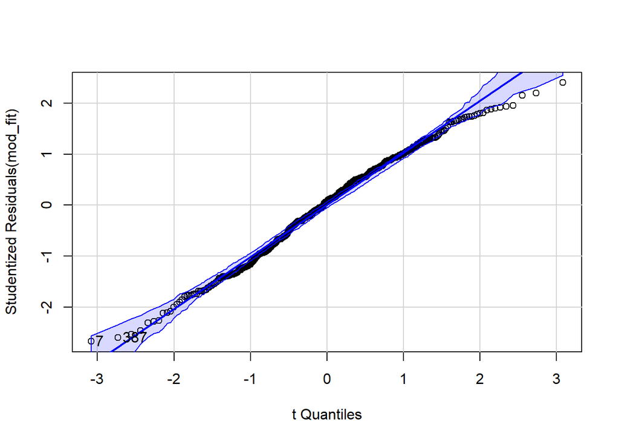

```
## [1]   7 387
```

```r
qqPlot(mod_fit) # не сильно отличается от нормального распредления визуально
```

```r
# тест на выбросы для mod soc -------
outlierTest(mod_fit, n.max = 10) # 7 - можно удалить
```

```
## No Studentized residuals with Bonferroni p < 0.05
## Largest |rstudent|:
##    rstudent unadjusted p-value Bonferroni p
## 7 -2.668116          0.0079082           NA
```

```r
# Leverages (outlying predictors) ----------------
head(hatvalues(mod_fit))
```

```
##          1          2          3          4          5          6
## 0.03382815 0.02283173 0.06458660 0.01564157 0.04667994 0.03537343
```

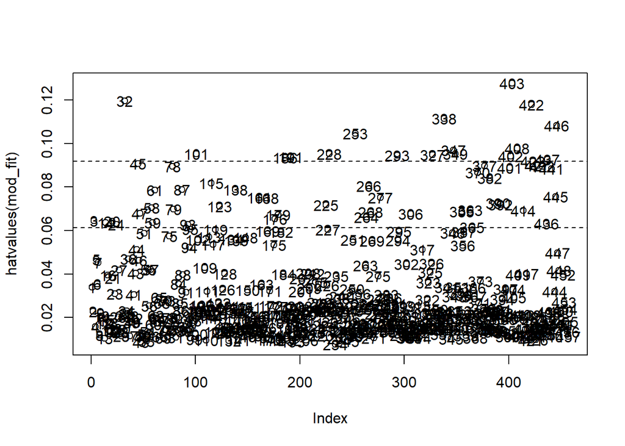

```r
plot(hatvalues(mod_fit))
#(2,3)*((k+1)/n), k - number of IVs (number of beta-coefficients), n - sample size,
abline(h=c(2,3)*14/457,lty=2)
text(hatvalues(mod_fit), rownames(df))
```

```r
# много наблюдений - влиятельные
# 403 и 32 - возможно удалить
```

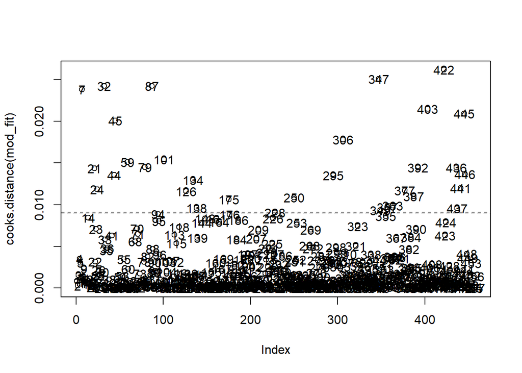

```r
# Cook’s distance for model with motivators ------
plot(cooks.distance(mod_fit))
text(cooks.distance(mod_fit), labels = rownames(df))
#4/(n-k-1), k - number of IVs (number of beta-coefficients), n - sample size,
abline(h=4/(457-13-1), lty=2)
```

```r
# множество наблюдений превышают жесткий порог рассмтояния Кука
# 7, 32, 87, 347, 422
```

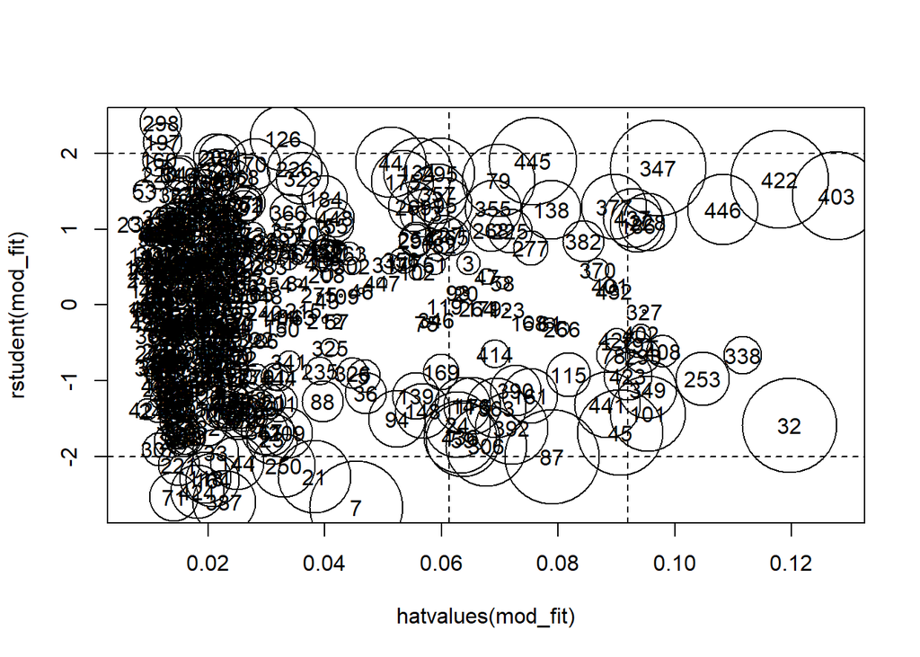

```r
plot(hatvalues(mod_fit), rstudent(mod_fit), type='n')
#thresholds for residuals
abline(h=c(-2, 2), lty=2)
#thresholds for leverages
abline(v=c(2,3)*14/457, lty=2)
cook <- sqrt(cooks.distance(mod_fit))
points(hatvalues(mod_fit), rstudent(mod_fit), cex=10*cook/max(cook))
text(hatvalues(mod_fit), rstudent(mod_fit), rownames(df))
```

```r
# наблюдения не сильно выходят за пределы двух сигм, однако некоторые очень сильно превышаю пороговое значение Кука
```

```r
# df betas для модели с мотиваторами -----
dfbs<- dfbetas(mod_fit)
head(dfbs)
```

```
##   (Intercept)         time FF_freqequally FF_freqmostly  FF_freqonly
## 1 -0.01501995 -0.012306182    0.004897225  0.0034456289  0.025068640
## 2  0.02193693 -0.039677690    0.004229049  0.0007235473  0.006943919
## 3  0.02609126  0.006094489   -0.004235353  0.0027977884 -0.006038889
## 4 -0.09264675  0.059460580   -0.007331574 -0.0366654701 -0.009708052
## 5  0.03791530  0.021110208   -0.009008430 -0.0257608972 -0.005457093
## 6 -0.02998063  0.062755646    0.004164209 -0.0007622578  0.026921407
##    genderMale  genderOther genderPrefer not to say           age       engYes
## 1 -0.04071750 -0.011169075            -0.021642799  5.962110e-02  0.004979359
## 2 -0.01775686 -0.002820667            -0.002455043  6.393921e-05 -0.004312681
## 3  0.02550356 -0.001803344            -0.006316839  4.047775e-02 -0.123587145
## 4  0.11228320  0.029607107             0.038828220  7.296369e-02 -0.010143336
## 5 -0.03884477  0.001528451            -0.001706126 -1.385743e-01 -0.012268217
## 6  0.02094207  0.006149231            -0.007740907  1.959907e-02  0.009843234
##        comfeel         disc    m_compet        m_esc
## 1 -0.037062636 -0.024811941  0.03002273  0.016320853
## 2 -0.009026406 -0.017651644 -0.01225567 -0.009556538
## 3  0.026735967  0.013008516 -0.04022803  0.003691889
## 4  0.077809241  0.086284007  0.01293743 -0.029897738
## 5  0.092214865  0.005583293  0.05177657 -0.047356608
## 6 -0.018992245  0.012215705  0.05463543 -0.002275548
```

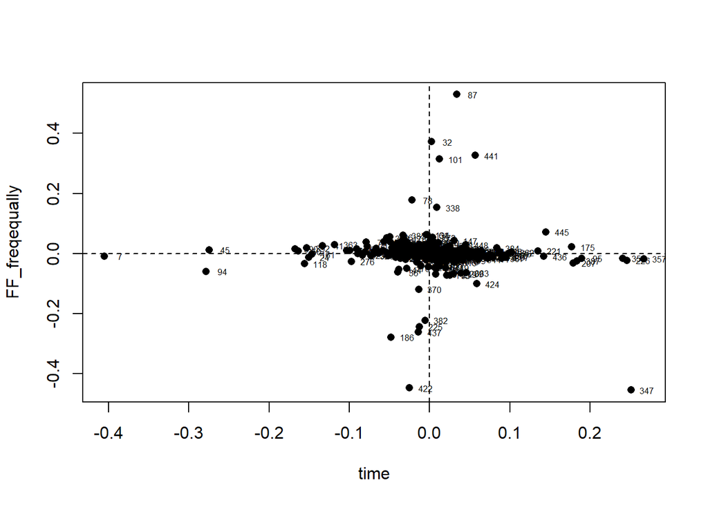

```r
plot(dfbs[,c(2,3)], pch = 16)
abline(v=0, lty=2)
abline(h=0, lty=2)
text(dfbs[,2] + 0.02, dfbs[,3], labels=row.names(df), cex = 0.5)
```

```r
# есть сильное отклонени
# 7 наблюдение - однозначно сильно отклоняет
```

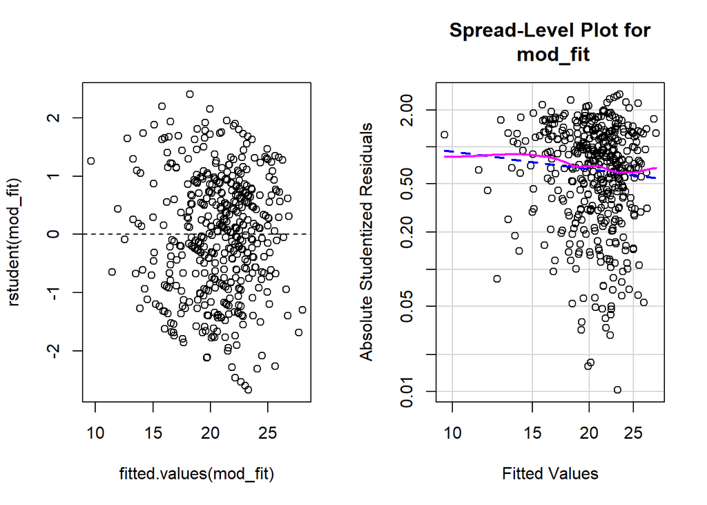

```
##
## Suggested power transformation:  1.487265
```

```r
# Heteroscedasticity for mod with motivators --------
par(mfrow = c(1, 2))
plot(fitted.values(mod_fit), rstudent(mod_fit))
abline(h=0, lty=2)
spreadLevelPlot(mod_fit)
```

```r
# нет признаков явной гетероскедастичности
```

```r
# formal test
ncvTest(mod_fit)
```

```
## Non-constant Variance Score Test
## Variance formula: ~ fitted.values
## Chisquare = 1.284452, Df = 1, p = 0.25707
```

```r
# в модели с мотиваторами нет гетероскедастичности -------
```

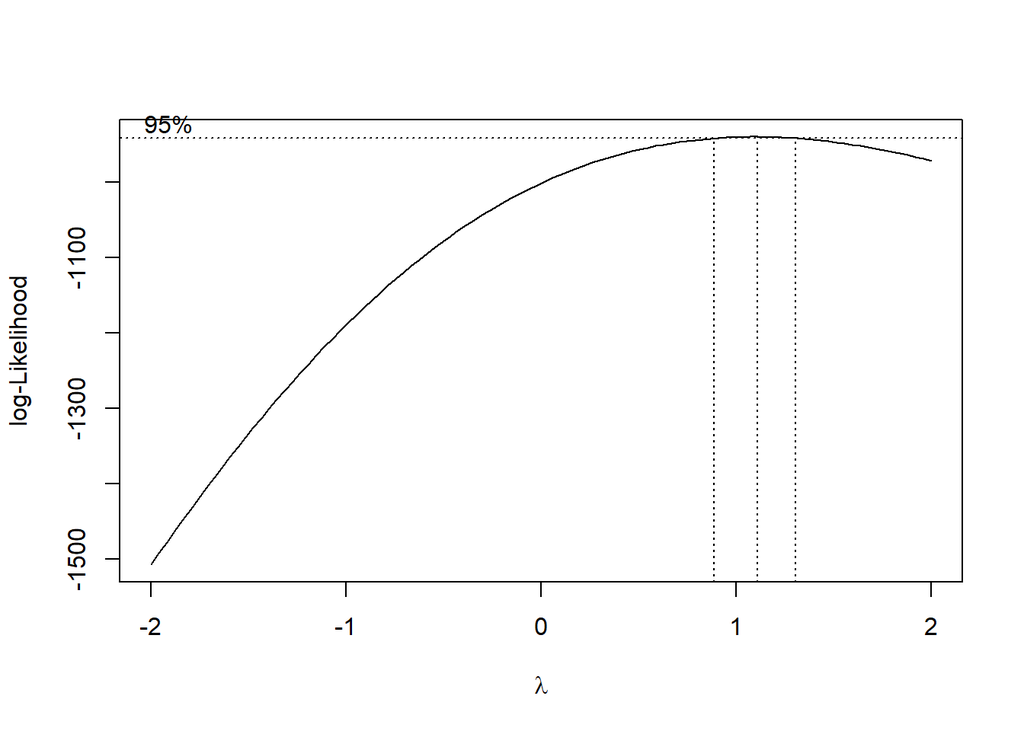

```r
# Non-linearity
# if lambda close to 0 - log
boxcox(mod_fit, data = df) # lambda is close to 1, no transformation necessary -------
```

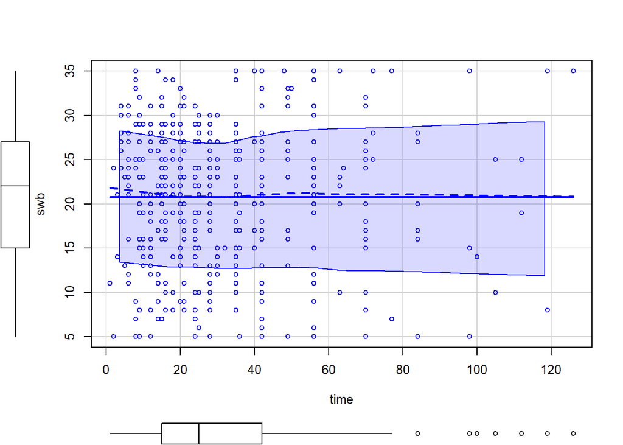

```r
# линейность связей --------
scatterplot(swb ~ time, data = df)
```

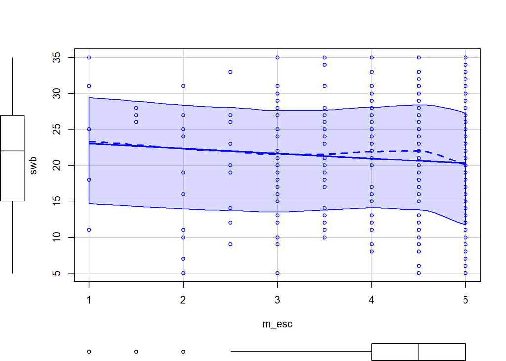

```r
scatterplot(swb ~ m_esc, data = df)
```

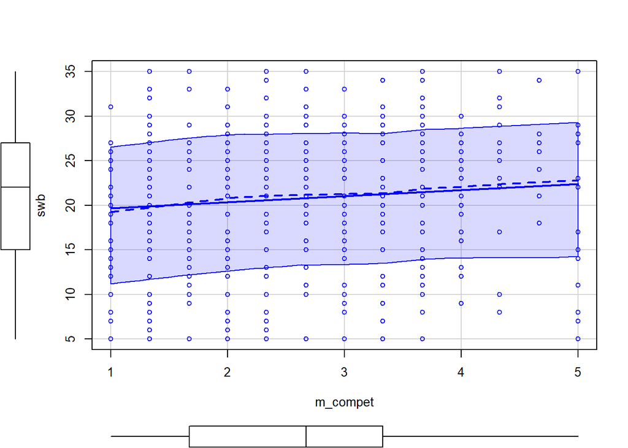

```r
scatterplot(swb ~ m_compet, data = df)
```

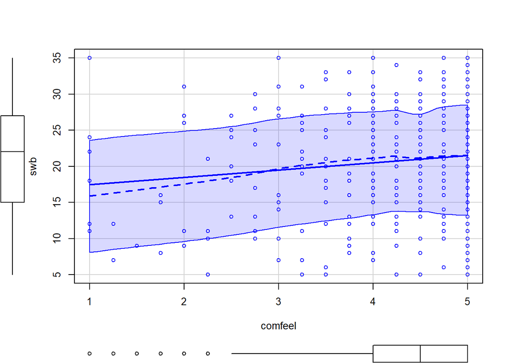

```r
scatterplot(swb ~ comfeel, data = df)
```

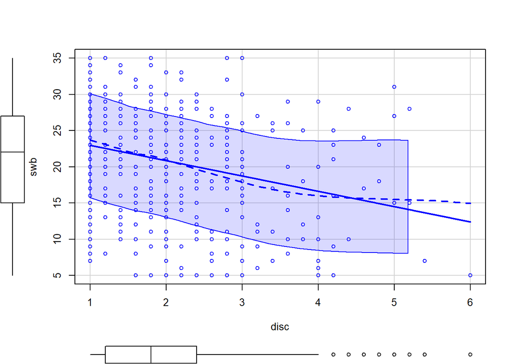

```r
scatterplot(swb ~ disc, data = df) # мб нелинейна связь
```

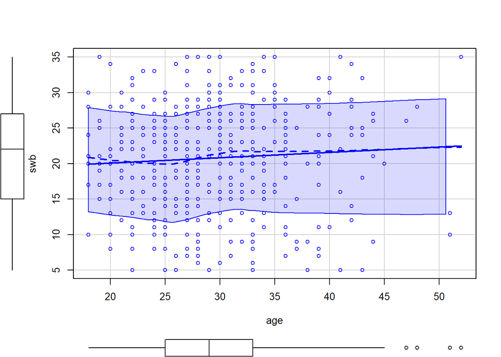

```r
scatterplot(swb ~ age, data = df)
```

```r
boxTidwell(swb ~ time + m_esc, data = df) # no log trans
```

```
##       MLE of lambda Score Statistic (z) Pr(>|z|)
## time         47.192              0.2720   0.7856
## m_esc       239.539             -0.2509   0.8019
##
## iterations =  26
```

```r
boxTidwell(swb ~ m_compet + comfeel + disc + age, data = df)
```

```
##          MLE of lambda Score Statistic (z) Pr(>|z|)
## m_compet      -0.16173             -0.5454  0.58547
## comfeel        0.40403             -0.6380  0.52346
## disc          -0.24597              2.1309  0.03309 *
## age            1.35948              0.2193  0.82644
## ---
## Signif. codes:  0 '***' 0.001 '**' 0.01 '*' 0.05 '.' 0.1 ' ' 1
##
## iterations =  26
```

```r
# disc - нужно логарифмировать переменную в модели -------
```

```r
vif(mod_fit)
```

```
##              GVIF Df GVIF^(1/(2*Df))
## time     1.143796  1        1.069484
## FF_freq  1.196178  3        1.030305
## gender   1.205081  3        1.031579
## age      1.062036  1        1.030551
## eng      1.018854  1        1.009383
## comfeel  1.222155  1        1.105511
## disc     1.045432  1        1.022464
## m_compet 1.127992  1        1.062070
## m_esc    1.208561  1        1.099346
```

```r
# нет мультиколлинеарности -----
```

#### Построение модели после диагностики

```r
# удаление выбросов и влиятельных наблюдений----
df_new = df[-which(rownames(df)=="7"|
                   rownames(df)=="422"|
                   rownames(df)=="403"|
                   rownames(df)=="32"), ]
```

```r
# построение финальной модели
mod_fin = lm(swb ~ m_esc + m_compet + comfeel + log(disc)
             + time + FF_freq + gender + age + eng,
             data = df_new)
```

```r
#summary(mod_fin)
```

```r
# распределения остатков для финальной модели ------
ols_test_normality(mod_fin)
```

```
## -----------------------------------------------
##        Test             Statistic       pvalue
## -----------------------------------------------
## Shapiro-Wilk              0.9893         0.0021
## Kolmogorov-Smirnov        0.0451         0.3153
## Cramer-von Mises         35.4193         0.0000
## Anderson-Darling          1.3906         0.0013
## -----------------------------------------------
```

```r
# распредление остатков все равно отличается от нормального
```

```r
par(mfrow=c(1,2), pty = "s")
qqPlot(mod_fin) # совсем не сильно отличается от нормального распредления визуально
```

```
## [1]  69 385
```

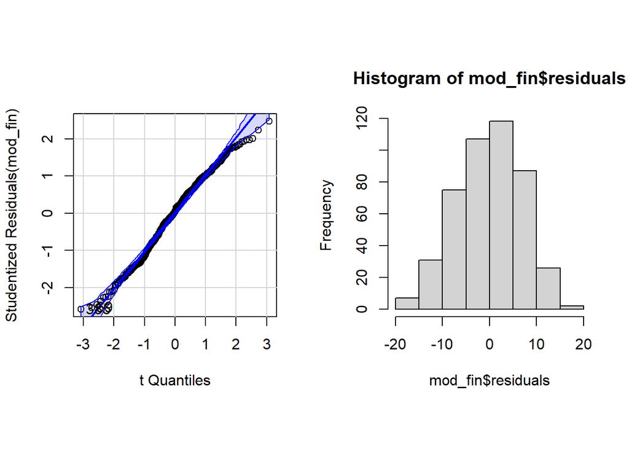

```r
hist(mod_fin$residuals)
```

```r
# тест на выбросы для финальной модели -------
outlierTest(mod_fin, n.max = 10) # 385 - можно удалить
```

```
## No Studentized residuals with Bonferroni p < 0.05
## Largest |rstudent|:
##      rstudent unadjusted p-value Bonferroni p
## 385 -2.580493            0.01019           NA
```

```r
# Leverages (outlying predictors) ----------------
head(hatvalues(mod_fin))
```

```
##          1          2          3          4          5          6
## 0.03365471 0.02403508 0.06707796 0.01741525 0.04680050 0.03647339
```

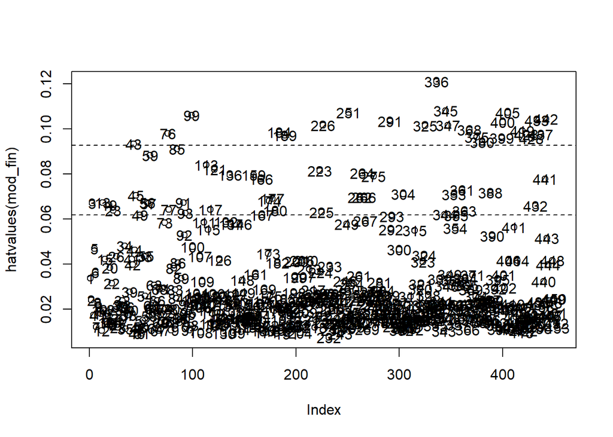

```r
plot(hatvalues(mod_fin))
#(2,3)*((k+1)/n), k - number of IVs (number of beta-coefficients), n - sample size,
abline(h=c(2,3)*14/453,lty=2)
text(hatvalues(mod_fin), rownames(df_new))
```

```r
# 336
```

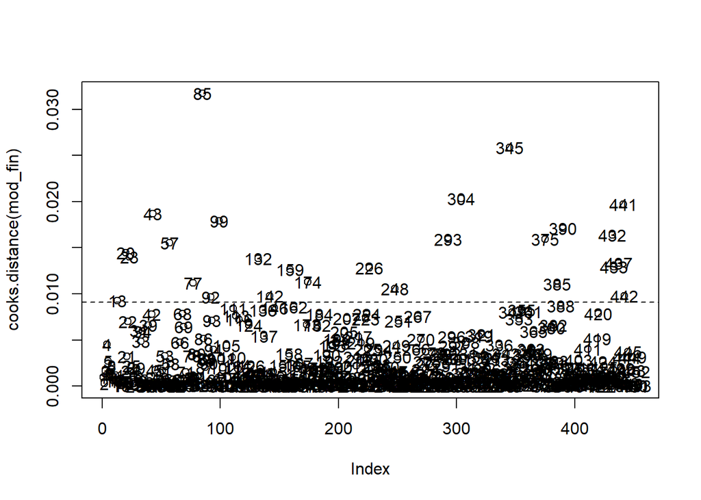

```r
# Cook’s distance for final model  ------
plot(cooks.distance(mod_fin))
text(cooks.distance(mod_fin), labels = rownames(df_new))
#4/(n-k-1), k - number of IVs (number of beta-coefficients), n - sample size,
abline(h=4/(453-13-1), lty=2)
```

```r
# 85
```

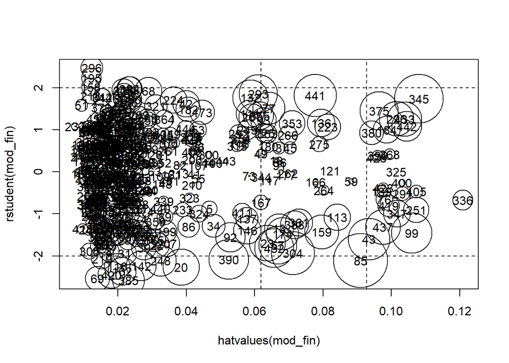

```r
plot(hatvalues(mod_fin), rstudent(mod_fin), type='n')
#thresholds for residuals
abline(h=c(-2, 2), lty=2)
#thresholds for leverages
abline(v=c(2,3)*14/453, lty=2)
cook <- sqrt(cooks.distance(mod_fin))
points(hatvalues(mod_fin), rstudent(mod_fin), cex=10*cook/max(cook))
text(hatvalues(mod_fin), rstudent(mod_fin), rownames(df_new))
```

```r
# наблюдения не сильно выходят за пределы двух сигм, однако некоторые  сильно превышаю пороговое значение Кука
```

```r
# df betas для финальной модели -----
dfbs<- dfbetas(mod_fin)
head(dfbs)
```

```
##   (Intercept)        m_esc     m_compet      comfeel    log(disc)         time
## 1 -0.01853870  0.017805772  0.032652187 -0.039415578 -0.023471304 -0.015369529
## 2  0.02130717 -0.008397186 -0.011616714 -0.009111825 -0.021230774 -0.041644509
## 3  0.03288184  0.001956939 -0.041798631  0.025651958  0.018503610  0.006803844
## 4 -0.09150102 -0.038705058  0.007653758  0.085035681  0.121328829  0.068788238
## 5  0.03616821 -0.044502031  0.049091726  0.086805696 -0.005256033  0.021200965
## 6 -0.03122772 -0.005367410  0.055403975 -0.018901564  0.020867152  0.067156797
##   FF_freqequally FF_freqmostly  FF_freqonly  genderMale  genderOther
## 1    0.006207821  0.0048029675  0.026933289 -0.04379508 -0.010370594
## 2    0.002632929 -0.0007238145  0.005559405 -0.01867063 -0.001584001
## 3   -0.009429856 -0.0027563709 -0.010935577  0.02647295 -0.001230444
## 4   -0.005696055 -0.0348003357 -0.008035972  0.12454948  0.031764026
## 5   -0.009138540 -0.0240698912 -0.005926351 -0.03749569  0.002747430
## 6    0.007157362  0.0024937060  0.029428671  0.02315012  0.007299481
##   genderPrefer not to say           age       engYes
## 1           -0.0243963504  0.0638033873  0.004826859
## 2           -0.0022144920  0.0002137847 -0.005131236
## 3           -0.0074084917  0.0403318633 -0.127549824
## 4            0.0409367020  0.0764602298 -0.008191323
## 5            0.0002312251 -0.1295883389 -0.010751355
## 6           -0.0099143946  0.0202865483  0.010644044
```

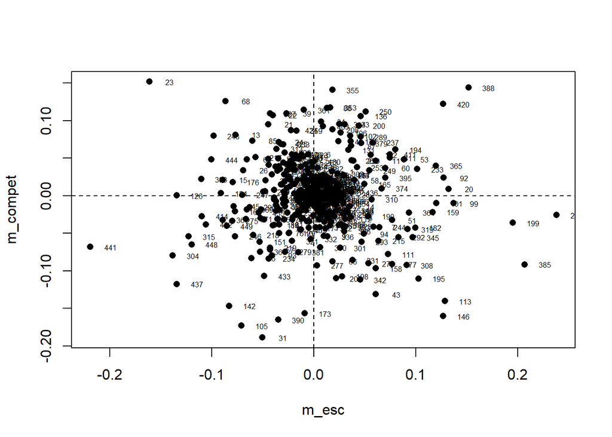

```r
plot(dfbs[,c(2,3)], pch = 16)
abline(v=0, lty=2)
abline(h=0, lty=2)
text(dfbs[,2] + 0.02, dfbs[,3], labels=row.names(df_new), cex = 0.5)
```

```r
# теперь наблюдения не меняют оценку параметров
```

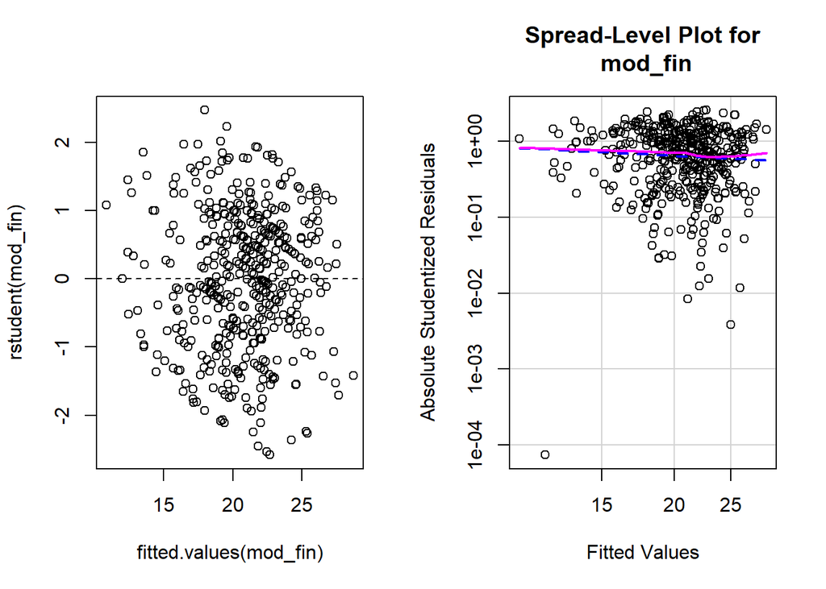

```
##
## Suggested power transformation:  1.375817
```

```r
# Heteroscedasticity for final mod --------
par(mfrow = c(1, 2))
plot(fitted.values(mod_fin), rstudent(mod_fin))
abline(h=0, lty=2)
spreadLevelPlot(mod_fin)
```

```r
# нет признаков явной гетероскедастичности
```

```r
# formal test
ncvTest(mod_fin)
```

```
## Non-constant Variance Score Test
## Variance formula: ~ fitted.values
## Chisquare = 0.8001808, Df = 1, p = 0.37104
```

```r
# в финальной моделе нет гетероскедастичности -------
```

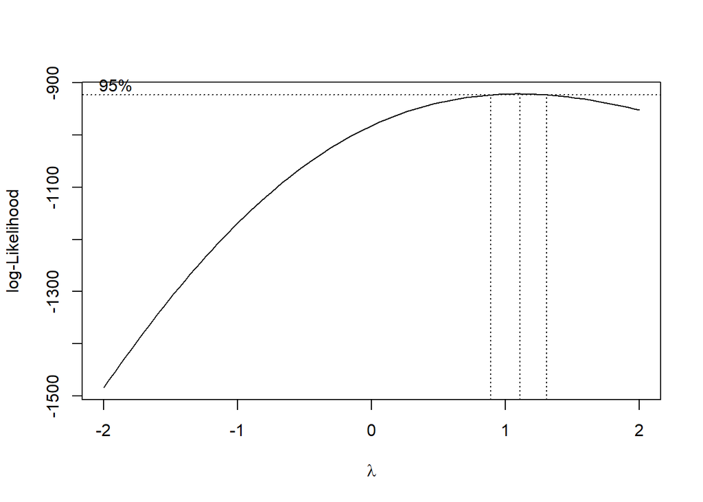

```r
# Non-linearity for final model --------
# if lambda close to 0 - log
boxcox(mod_fin, data = df_new) # lambda is close to 1, no transformation necessary -------
```

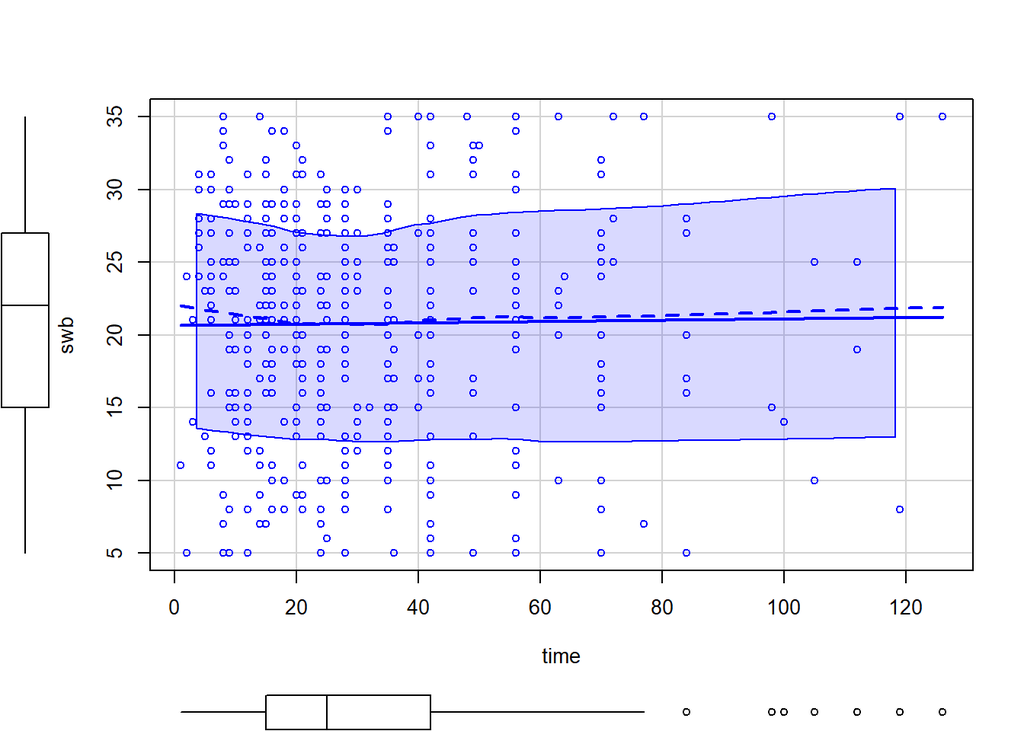

```r
# линейность связей --------
scatterplot(swb ~ time, data = df_new)
```

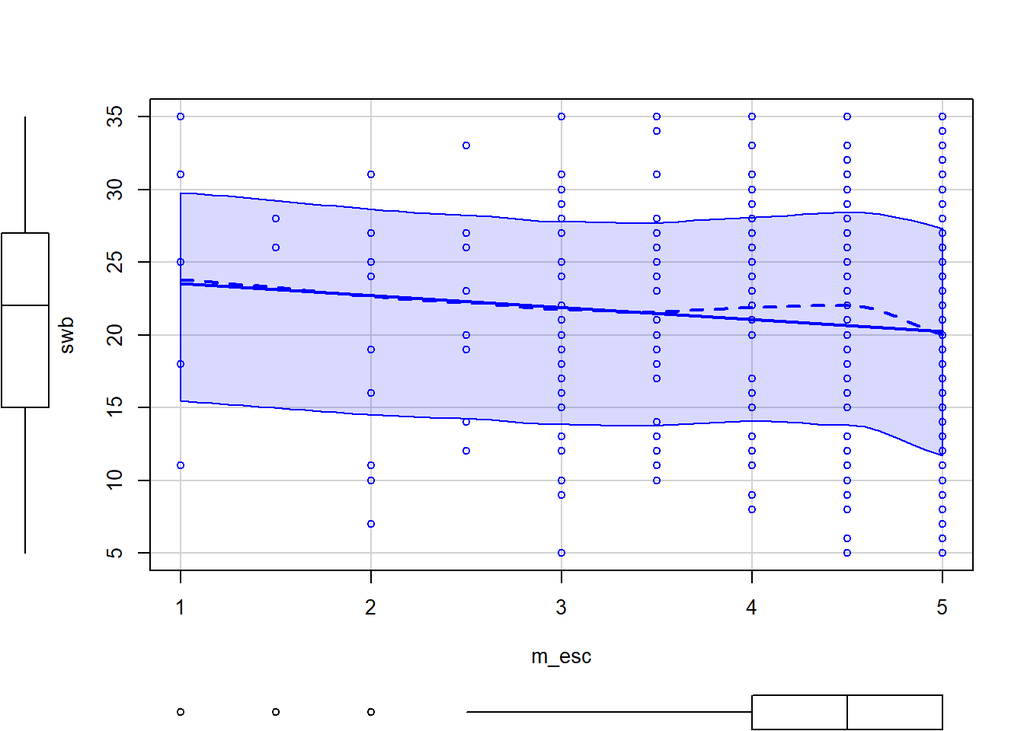

```r
scatterplot(swb ~ m_esc, data = df_new)
```

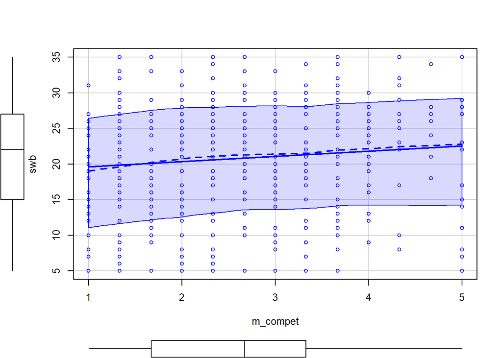

```r
scatterplot(swb ~ m_compet, data = df_new)
```

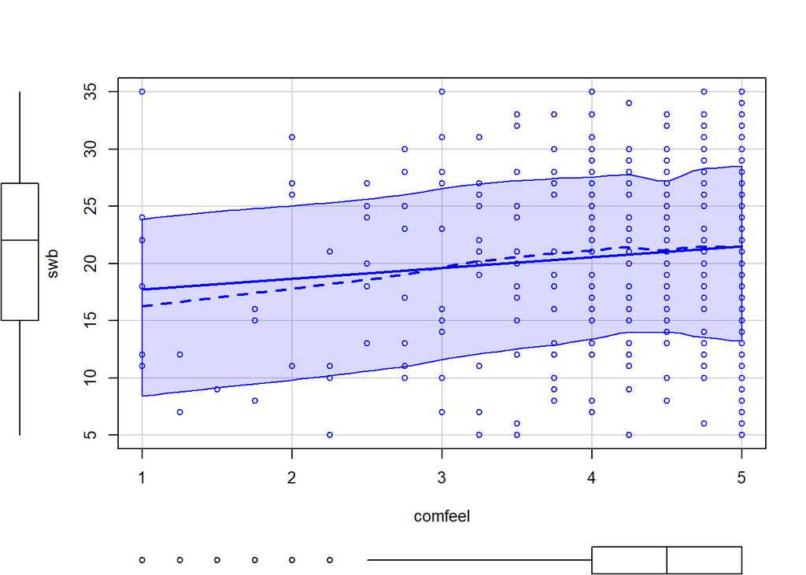

```r
scatterplot(swb ~ comfeel, data = df_new)
```

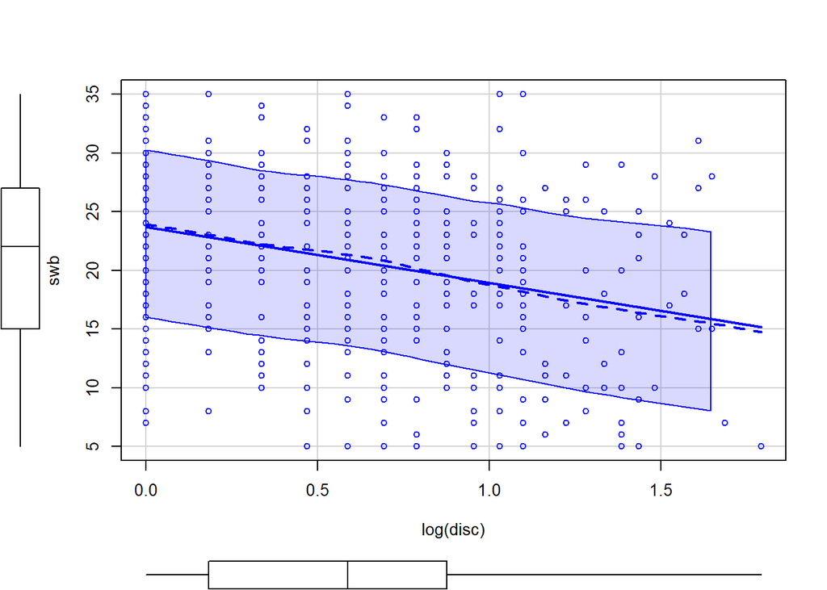

```r
scatterplot(swb ~ log(disc), data = df_new) # теперь связь линейна
```

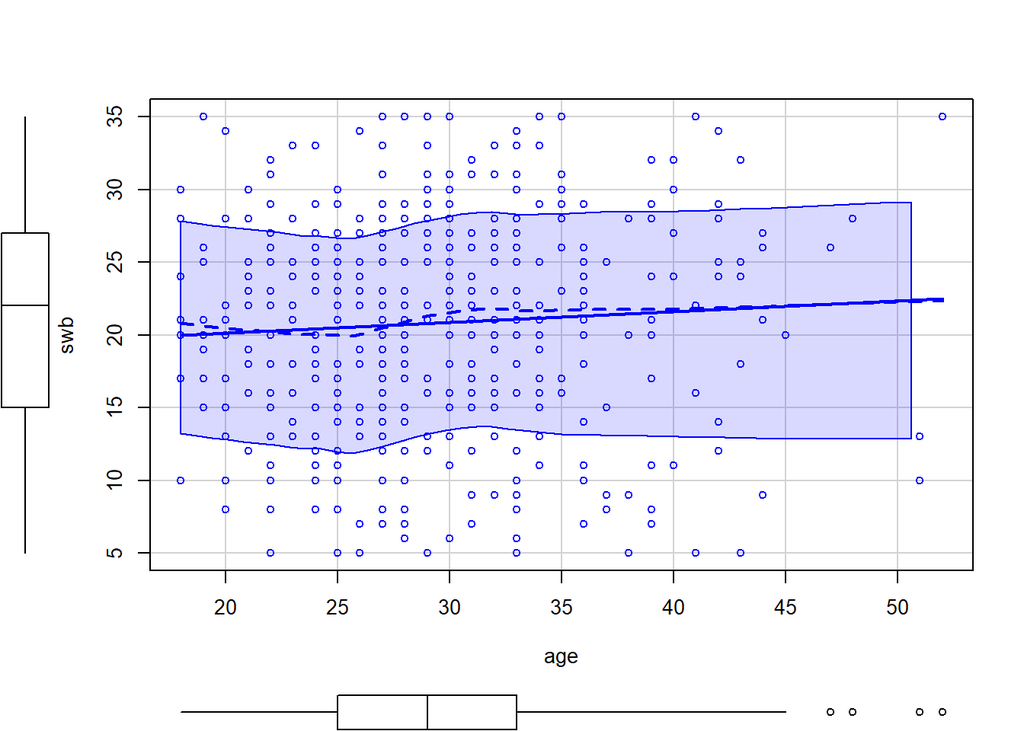

```r
scatterplot(swb ~ age, data = df_new)
```

```r
boxTidwell(swb ~ time, data = df_new) # no log trans
```

```
##  MLE of lambda Score Statistic (z) Pr(>|z|)
##         49.811              0.8152    0.415
##
## iterations =  7
```

```r
boxTidwell(swb ~ m_esc, data = df_new)
```

```
##  MLE of lambda Score Statistic (z) Pr(>|z|)
##         42.295             -0.1732   0.8625
##
## iterations =  11
```

```r
boxTidwell(swb ~ m_compet + comfeel + age, data = df_new)
```

```
##          MLE of lambda Score Statistic (z) Pr(>|z|)
## m_compet      -0.60563             -0.9064   0.3647
## comfeel        0.62175             -0.3441   0.7308
## age            1.97742              0.4709   0.6377
##
## iterations =  26
```

```r
vif(mod_fin)
```

```
##               GVIF Df GVIF^(1/(2*Df))
## m_esc     1.225552  1        1.107047
## m_compet  1.130853  1        1.063416
## comfeel   1.224399  1        1.106526
## log(disc) 1.043935  1        1.021732
## time      1.135330  1        1.065519
## FF_freq   1.187205  3        1.029013
## gender    1.212227  3        1.032597
## age       1.060852  1        1.029977
## eng       1.020723  1        1.010308
```

```r
# нет мультиколлинеарности -----
```

- **Несмотря на наличие нескольких влиятельных наблюдений, остальные ограничения МНК-регрессии не нарушаются: остатки распредлены нормально, нет мультиколлинеарности и гетероскедостичности.**
- **Более того, влиятельные наблюдения в лучшей версии модели не изменяют оценки параметров.**

#### Интерпретация финальной модели subjective well-being

```r
tab_model(mod_fin, show.ci=F,
          pred.labels = c("(Константа)", 'мотиватор "escapists"', 'мотиватор "competitors"',
                          "чувство сообщества", "опыт дискриминации (log)",
                          "игровое время (час/нед)","FFXIV: наравне",
                          "FFXIV: по большей части", "FFXIV: только",
                          "гендер: М", "гендер: Другое",
                          "гендер: Не скажу", "возраст", "свободный англ: Да"),
          dv.labels = "субъективное благополучие",
          string.est = "β",
          string.p = "p-value",
          string.pred = "Предикторы")
```

|  | субъективное благополучие |  |
| --- | --- | --- |
| Предикторы | β | p-value |
| (Константа) | 14.62 | **<0.001** |
| мотиватор “escapists” | -1.05 | **0.009** |
| мотиватор “competitors” | 0.75 | **0.021** |
| чувство сообщества | 1.27 | **0.002** |
| опыт дискриминации (log) | -4.66 | **<0.001** |
| игровое время (час/нед) | 0.01 | 0.519 |
| FFXIV: наравне | 3.12 | 0.134 |
| FFXIV: по большей части | 1.46 | 0.476 |
| FFXIV: только | 2.72 | 0.210 |
| гендер: М | 0.31 | 0.681 |
| гендер: Другое | -7.02 | **0.001** |
| гендер: Не скажу | -4.19 | **0.010** |
| возраст | 0.12 | **0.021** |
| свободный англ: Да | 0.25 | 0.876 |
| Observations | 453 |  |
| R<sup>2</sup> / R<sup>2</sup> adjusted | 0.172 / 0.148 |  |

**Влияние мотиваторов на уровень СУБ** - С повышением индекса мотивации “Escapists” на 1 балл уровень СУБ понижается на 1.05 баллов. - H3 подтвердилась, повышение значении мотивации в эскапизме дейсвительно негативно связано с уровнем удовлетворенностью жизни. - С повышением индекса мотивации “Competitors” на 1 балл уровень СУБ повышается на 0.75 баллов. - Не было предусмотрено гипотезами.

**Влияние чувства сообщества онлйан** - С повышением индекса чувства сообщества на 1 балл уровень СУБ повышается на 1.27 баллов. - H4 также подтвердилась - Ограничение вывода: вероятно, опрос могли проходить люди, которые изначально чувствовали большую связь с сообществом игроков FFXIV. - С другой стороны, это может быть осоенностью конкретной игры и даже жанра ММОРПГ в целом. В ММОРПГ геймплейные элементы создают большие возможности для социальной игры по сравнению с другими жанрами (особенно MOBA).

**Влияние испытываемого опыта социальной дискриминации в FFXIV** - Повышение оценки опыта дискриминации на 1% сопровождается понижением уровня СУБ на 4.66/100=0.05 балла - H5 подтвердилась - Вероятно, это особенность жанра. Играя в ММОРПГ, пользователи в большей степени погружаются в виртуальный мир (создание и отыгрывание персонажа, долгие совместные преключения - практически вторая полноценная жизнь). Конексты “виртуальной” и “реальной” жизни могут смешиваться.

**Влияние игрового времени** - Повышение игрового времени не связано с СУБ. - Удивительно, но вопроеки H1, игровое время не влияет на удовлетворенность жизнью игроков.

**Влияние возраста** - С повышением возраста игроков на 1 год уровень СУБ повышается на 0.12 баллов.

#### Визуализация итоговой модели для СУБ

```r
pl1 = plot_model(mod_fin, type = "pred",
           terms = "m_esc",
           title = "",
           axis.title = c('мотиватор "escapists"', "субъективное благополучие")) +
           theme_sjplot()
pl2 = plot_model(mod_fin, type = "pred",
           terms = "m_compet",
           title = "",
           axis.title = c('мотиватор "competitors"', "субъективное благополучие")) +
           theme_sjplot()
pl3 = plot_model(mod_fin, type = "pred",
           terms = "comfeel",
           title = "",
           axis.title = c('чувство сообщества', "субъективное благополучие")) +
           theme_sjplot()
pl4 = plot_model(mod_fin, type = "pred",
           terms = "disc",
           title = "",
           axis.title = c('опыт дискриминации в FFXIV', "субъективное благополучие")) +
           theme_sjplot()
```

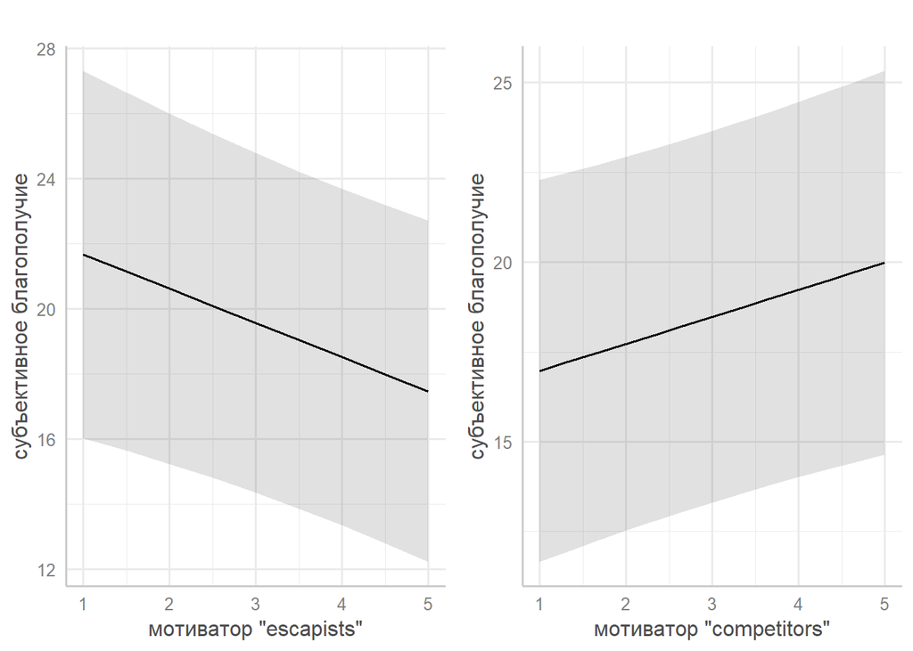

```r
cowplot::plot_grid(pl1, pl2)
```

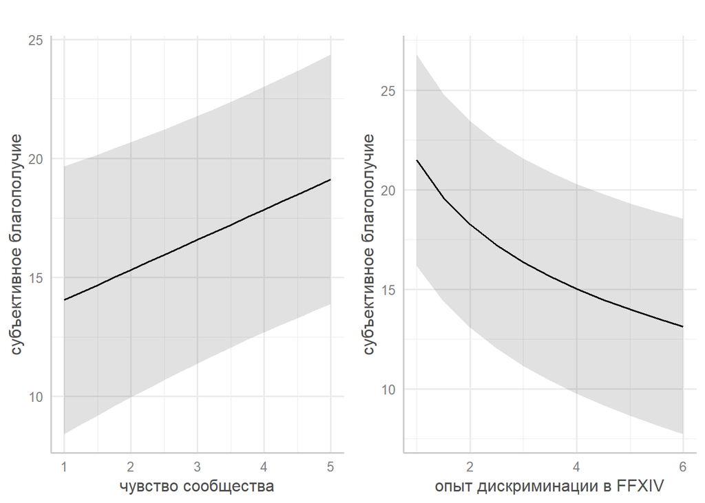

```r
cowplot::plot_grid(pl3, pl4)
```

```r
df_new3 = df_new
df_new3$FF_freq_ru = as.factor(df_new3$FF_freq_ru)
df_new3$FF_freq_ru = relevel(df_new3$FF_freq_ru, ref = "по меньшей части")
mod_fin2 = lm(swb ~ time + m_compet + m_esc + log(disc) + FF_freq_ru + gender + age + eng, data = df_new3)
pl5 = plot_model(mod_fin2, type = "pred",
           terms = "FF_freq_ru",
           title = "",
           axis.title = c('Насколько часто играете в FFXIV по сравнению с другими онлайн-играми?', "субъективное благополучие")) +
           theme_sjplot()
```

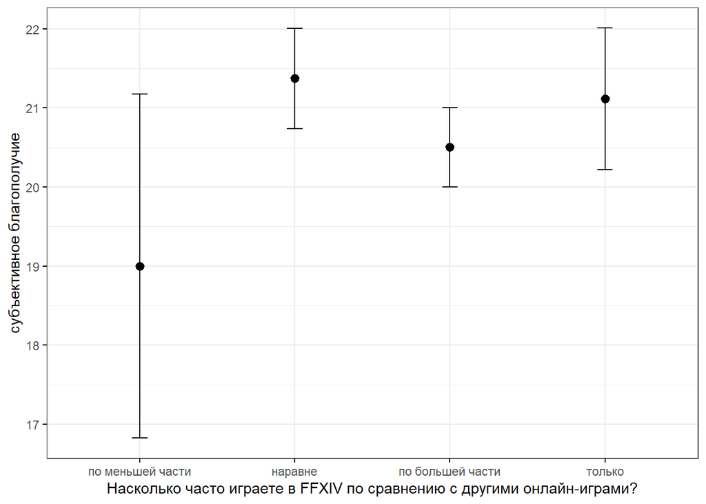

```r
# errorbars for FFXIV_freq -------
ggerrorplot(data = df_new3,
            x = 'FF_freq_ru',
            y = 'swb',
            add = "mean",
            error.plot = "errorbar",
            ggtheme = theme_bw(),
            xlab = 'Насколько часто играете в FFXIV по сравнению с другими онлайн-играми?',
            ylab = 'субъективное благополучие')
```

- Наблюдается разница в размахе данных вокруг среднего значения в четырех подвыборках.
- В первой категории данные в большей степени отличаются от среднего по сравнению с тремя другими.
- Категория “Играю наименьше всего в FFXIV по сравнению с другими онлайн-играми” включает в себя всего лишь 3% наблюдений из набора данных, поэтому наблюдается значительная разница в том, насколько точно средние репрезентуют данные в выборках.

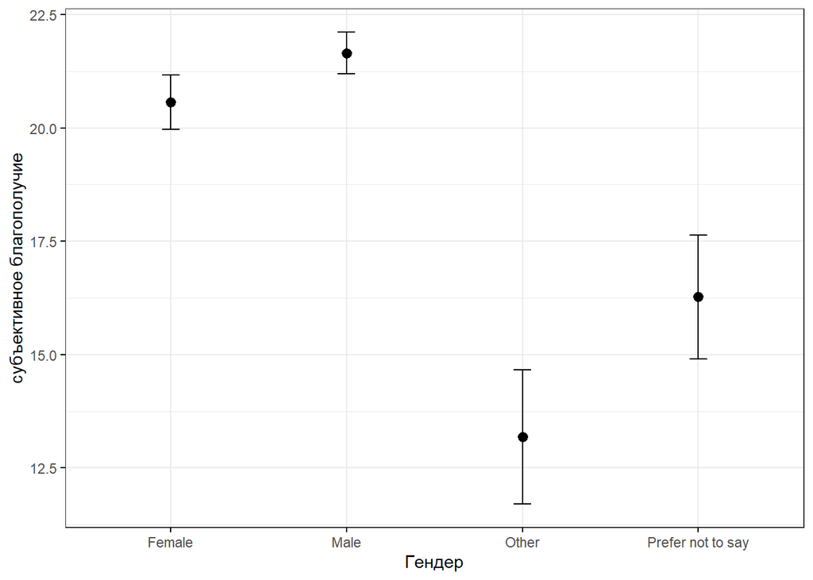

```r
# errorbars for gender -------
ggerrorplot(data = df_new3,
            x = 'gender',
            y = 'swb',
            error.plot = "errorbar",
            add = "mean",
            ggtheme = theme_bw(),
            xlab = 'Гендер',
            ylab = 'субъективное благополучие')
```

#### Представление в виде вложенных моделей

```r
# иерархическая регрессия --------
tab_model(m_null, m_cmpt, m_cmpt_esc, show.ci = F,
          pred.labels = c("(Константа)","игровое время (час/нед)", "чувство сообщества",
                          "опыт дискриминации", "FFXIV: наравне",
                          "FFXIV: по большей части", "FFXIV: только",
                          "гендер: М", "гендер: Другое",
                          "гендер: Не скажу", "возраст", "свободный англ: Да",
                          'мотиватор "competitors"',
                          'мотиватор "escapists"'),
          dv.labels = c("(1)", "(2)", "(3)"),
          string.est = "β",
          string.p = "p-value",
          string.pred = "Предикторы")
```

|  | (1) |  | (2) |  | (3) |  |
| --- | --- | --- | --- | --- | --- | --- |
| Предикторы | β | p-value | β | p-value | β | p-value |
| (Константа) | 15.37 | **<0.001** | 13.44 | **<0.001** | 15.76 | **<0.001** |
| игровое время (час/нед) | 0.01 | 0.485 | 0.01 | 0.699 | 0.01 | 0.610 |
| чувство сообщества | 2.21 | 0.266 | 2.49 | 0.210 | 2.94 | 0.137 |
| опыт дискриминации | 0.56 | 0.774 | 0.84 | 0.668 | 1.29 | 0.508 |
| FFXIV: наравне | 2.02 | 0.332 | 2.27 | 0.274 | 2.69 | 0.195 |
| FFXIV: по большей части | 0.91 | 0.216 | 0.53 | 0.486 | 0.31 | 0.685 |
| FFXIV: только | -6.88 | **0.002** | -6.56 | **0.002** | -6.58 | **0.002** |
| гендер: М | -3.37 | **0.040** | -3.46 | **0.034** | -3.53 | **0.029** |
| гендер: Другое | 0.11 | **0.047** | 0.12 | **0.028** | 0.12 | **0.025** |
| гендер: Не скажу | 0.51 | 0.754 | 0.61 | 0.706 | 0.78 | 0.624 |
| возраст | 0.96 | **0.014** | 0.93 | **0.017** | 1.31 | **0.002** |
| свободный англ: Да | -2.05 | **<0.001** | -2.12 | **<0.001** | -2.08 | **<0.001** |
| мотиватор “competitors” |  |  | 0.71 | **0.032** | 0.68 | **0.039** |
| мотиватор “escapists” |  |  |  |  | -1.06 | **0.007** |
| Observations | 457 |  | 457 |  | 457 |  |
| R<sup>2</sup> / R<sup>2</sup> adjusted | 0.133 / 0.112 |  | 0.142 / 0.119 |  | 0.156 / 0.131 |  |

```r
# модель без мотиваторов ------
m_null = lm(swb ~ time + FF_freq + gender + age + eng + comfeel + log(disc), data = df)
#summary(m_null)
```

```r
# добавление мотиватора compet
m_cmpt <- update(m_null, . ~ . + m_compet)
#summary(m_cmpt)
```

```r
# добавление мотиватора escapists
m_cmpt_esc <- update(m_cmpt, . ~ . + m_esc)
#summary(m_cmpt_esc)
```

```r
mod_fin_tab = lm(swb ~ time + FF_freq + gender + age + eng + comfeel + log(disc) + m_compet + m_esc, data = df_new)
```

```r
# иерархическая регрессия для финальной модели --------
tab_model(m_null, m_cmpt, mod_fin_tab, show.ci = F,
          pred.labels = c("(Константа)","игровое время (час/нед)",
                          "FFXIV: по большей части", "FFXIV: только","FFXIV: наравне",
                          "гендер: М", "гендер: Другое",
                          "гендер: Не скажу", "возраст", "свободный англ: Да",
                          "чувство сообщества",
                          "опыт дискриминации [log]",
                          'мотиватор "competitors"',
                          'мотиватор "escapists"'),
          dv.labels = c("(1)", "(2)", "(3)"),
          string.est = "β",
          string.p = "p-value",
          string.pred = "Предикторы")
```

|  | (1) |  | (2) |  | (3) |  |
| --- | --- | --- | --- | --- | --- | --- |
| Предикторы | β | p-value | β | p-value | β | p-value |
| (Константа) | 13.70 | **<0.001** | 11.59 | **0.001** | 14.62 | **<0.001** |
| игровое время (час/нед) | 0.01 | 0.637 | 0.00 | 0.893 | 0.01 | 0.519 |
| FFXIV: по большей части | 2.21 | 0.266 | 2.51 | 0.206 | 3.12 | 0.134 |
| FFXIV: только | 0.59 | 0.764 | 0.88 | 0.652 | 1.46 | 0.476 |
| FFXIV: наравне | 2.08 | 0.317 | 2.35 | 0.257 | 2.72 | 0.210 |
| гендер: М | 0.88 | 0.232 | 0.47 | 0.536 | 0.31 | 0.681 |
| гендер: Другое | -6.56 | **0.002** | -6.20 | **0.004** | -7.02 | **0.001** |
| гендер: Не скажу | -3.39 | **0.038** | -3.48 | **0.032** | -4.19 | **0.010** |
| возраст | 0.11 | **0.046** | 0.12 | **0.025** | 0.12 | **0.021** |
| свободный англ: Да | 0.56 | 0.726 | 0.67 | 0.675 | 0.25 | 0.876 |
| чувство сообщества | 1.02 | **0.009** | 0.99 | **0.010** | 1.27 | **0.002** |
| опыт дискриминации [log] | -4.52 | **<0.001** | -4.72 | **<0.001** | -4.66 | **<0.001** |
| мотиватор “competitors” |  |  | 0.76 | **0.023** | 0.75 | **0.021** |
| мотиватор “escapists” |  |  |  |  | -1.05 | **0.009** |
| Observations | 457 |  | 457 |  | 453 |  |
| R<sup>2</sup> / R<sup>2</sup> adjusted | 0.138 / 0.116 |  | 0.148 / 0.125 |  | 0.172 / 0.148 |  |

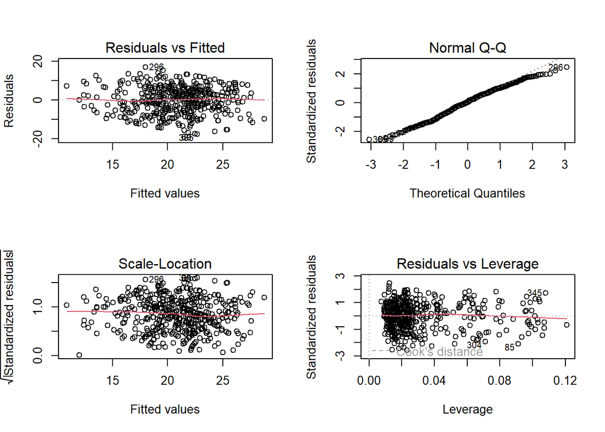

```r
par(mfrow=c(2,2), s = 'pty')
plot(mod_fin_tab)
```

#### Добавление эффектов взаимодейсвия

```r
mod_int_esc = lm(swb ~ comfeel + disc + FF_freq + gender + age + eng + time*m_esc, data = df_new)
mod_int_soc = lm(swb ~ comfeel + disc + FF_freq + gender + age + eng + time*m_soc, data = df_new)
mod_int_compet = lm(swb ~ comfeel + disc + FF_freq + gender + age + eng + time*m_compet, data = df_new)
summary(mod_int_esc)
```

```
##
## Call:
## lm(formula = swb ~ comfeel + disc + FF_freq + gender + age +
##     eng + time * m_esc, data = df_new)
##
## Residuals:
##      Min       1Q   Median       3Q      Max
## -18.1555  -5.2792   0.4121   5.1843  16.6347
##
## Coefficients:
##                          Estimate Std. Error t value Pr(>|t|)
## (Intercept)             19.384115   4.049346   4.787 2.32e-06 ***
## comfeel                  1.258580   0.412164   3.054 0.002399 **
## disc                    -2.027868   0.354745  -5.716 2.01e-08 ***
## FF_freqequally           2.929661   2.112263   1.387 0.166152
## FF_freqmostly            1.249795   2.080999   0.601 0.548434
## FF_freqonly              2.493836   2.197315   1.135 0.257017
## genderMale               0.757514   0.731716   1.035 0.301119
## genderOther             -7.572265   2.209189  -3.428 0.000666 ***
## genderPrefer not to say -3.997977   1.639246  -2.439 0.015127 *
## age                      0.110378   0.053977   2.045 0.041461 *
## engYes                   0.100432   1.625466   0.062 0.950761
## time                    -0.013417   0.075750  -0.177 0.859494
## m_esc                   -1.340160   0.623751  -2.149 0.032216 *
## time:m_esc               0.007597   0.016933   0.449 0.653895
## ---
## Signif. codes:  0 '***' 0.001 '**' 0.01 '*' 0.05 '.' 0.1 ' ' 1
##
## Residual standard error: 7.03 on 439 degrees of freedom
## Multiple R-squared:  0.1592, Adjusted R-squared:  0.1343
## F-statistic: 6.396 on 13 and 439 DF,  p-value: 3.898e-11
```

```r
summary(mod_int_soc)
```

```
##
## Call:
## lm(formula = swb ~ comfeel + disc + FF_freq + gender + age +
##     eng + time * m_soc, data = df_new)
##
## Residuals:
##      Min       1Q   Median       3Q      Max
## -17.9029  -5.0965   0.6327   5.5742  15.9290
##
## Coefficients:
##                          Estimate Std. Error t value Pr(>|t|)
## (Intercept)             17.521462   3.874560   4.522 7.89e-06 ***
## comfeel                  0.539765   0.471527   1.145 0.252951
## disc                    -2.171662   0.361702  -6.004 4.04e-09 ***
## FF_freqequally           2.587320   2.104717   1.229 0.219619
## FF_freqmostly            0.856173   2.075770   0.412 0.680203
## FF_freqonly              2.214561   2.199054   1.007 0.314465
## genderMale               1.020043   0.731463   1.395 0.163865
## genderOther             -7.877578   2.219169  -3.550 0.000427 ***
## genderPrefer not to say -3.925193   1.649440  -2.380 0.017752 *
## age                      0.108091   0.055195   1.958 0.050822 .
## engYes                  -0.060674   1.633344  -0.037 0.970385
## time                    -0.041190   0.056567  -0.728 0.466901
## m_soc                    0.009669   0.591412   0.016 0.986964
## time:m_soc               0.015359   0.014610   1.051 0.293724
## ---
## Signif. codes:  0 '***' 0.001 '**' 0.01 '*' 0.05 '.' 0.1 ' ' 1
##
## Residual standard error: 7.075 on 439 degrees of freedom
## Multiple R-squared:  0.1483, Adjusted R-squared:  0.1231
## F-statistic: 5.881 on 13 and 439 DF,  p-value: 4.536e-10
```

```r
summary(mod_int_compet)
```

```
##
## Call:
## lm(formula = swb ~ comfeel + disc + FF_freq + gender + age +
##     eng + time * m_compet, data = df_new)
##
## Residuals:
##     Min      1Q  Median      3Q     Max
## -18.097  -4.920   0.411   5.128  16.668
##
## Coefficients:
##                         Estimate Std. Error t value Pr(>|t|)
## (Intercept)             15.71757    3.80015   4.136 4.24e-05 ***
## comfeel                  0.81632    0.38557   2.117 0.034807 *
## disc                    -2.14078    0.35622  -6.010 3.91e-09 ***
## FF_freqequally           2.69910    2.09216   1.290 0.197695
## FF_freqmostly            1.01407    2.06256   0.492 0.623210
## FF_freqonly              2.17537    2.17952   0.998 0.318781
## genderMale               0.60033    0.74863   0.802 0.423039
## genderOther             -7.72862    2.21132  -3.495 0.000522 ***
## genderPrefer not to say -4.18590    1.64298  -2.548 0.011182 *
## age                      0.11669    0.05438   2.146 0.032430 *
## engYes                   0.03101    1.62530   0.019 0.984785
## time                    -0.03303    0.03768  -0.877 0.381131
## m_compet                 0.20244    0.52884   0.383 0.702058
## time:m_compet            0.01593    0.01208   1.319 0.187904
## ---
## Signif. codes:  0 '***' 0.001 '**' 0.01 '*' 0.05 '.' 0.1 ' ' 1
##
## Residual standard error: 7.039 on 439 degrees of freedom
## Multiple R-squared:  0.1572, Adjusted R-squared:  0.1322
## F-statistic: 6.298 on 13 and 439 DF,  p-value: 6.208e-11
```

```r
vif(mod_int_esc)
```

```
##                 GVIF Df GVIF^(1/(2*Df))
## comfeel     1.226935  1        1.107671
## disc        1.038994  1        1.019310
## FF_freq     1.208661  3        1.032090
## gender      1.136083  3        1.021492
## age         1.051829  1        1.025587
## eng         1.022050  1        1.010965
## time       25.090345  1        5.009026
## m_esc       2.957506  1        1.719740
## time:m_esc 27.991476  1        5.290697
```

```r
vif(mod_int_soc)
```

```
##                 GVIF Df GVIF^(1/(2*Df))
## comfeel     1.585230  1        1.259059
## disc        1.066297  1        1.032617
## FF_freq     1.194977  3        1.030133
## gender      1.113044  3        1.018010
## age         1.085717  1        1.041978
## eng         1.018751  1        1.009332
## time       13.812514  1        3.716519
## m_soc       3.291770  1        1.814323
## time:m_soc 16.675282  1        4.083538
```

```r
vif(mod_int_compet)
```

```
##                   GVIF Df GVIF^(1/(2*Df))
## comfeel       1.071097  1        1.034938
## disc          1.045122  1        1.022312
## FF_freq       1.185918  3        1.028827
## gender        1.196134  3        1.030299
## age           1.064922  1        1.031951
## eng           1.019361  1        1.009634
## time          6.192037  1        2.488380
## m_compet      2.936319  1        1.713569
## time:m_compet 8.712030  1        2.951615
```

- Мотивация не оказывает эффект модерации на связь между игровым временем и СУБ.

```r
mod_int_disc = lm(swb ~ time + m_compet + comfeel*disc + FF_freq + gender + age + eng, data = df_new)
summary(mod_int_disc)
```

```
##
## Call:
## lm(formula = swb ~ time + m_compet + comfeel * disc + FF_freq +
##     gender + age + eng, data = df_new)
##
## Residuals:
##      Min       1Q   Median       3Q      Max
## -18.3001  -5.1015   0.4185   5.2545  16.7071
##
## Coefficients:
##                         Estimate Std. Error t value Pr(>|t|)
## (Intercept)             12.57204    4.50086   2.793 0.005446 **
## time                     0.01223    0.01619   0.756 0.450336
## m_compet                 0.74851    0.32766   2.284 0.022822 *
## comfeel                  1.19711    0.77929   1.536 0.125219
## disc                    -1.42500    1.35230  -1.054 0.292573
## FF_freqequally           2.71977    2.09565   1.298 0.195032
## FF_freqmostly            1.01484    2.06644   0.491 0.623596
## FF_freqonly              2.22358    2.18361   1.018 0.309096
## genderMale               0.55249    0.74977   0.737 0.461585
## genderOther             -7.64564    2.21428  -3.453 0.000608 ***
## genderPrefer not to say -4.09023    1.64419  -2.488 0.013228 *
## age                      0.12073    0.05436   2.221 0.026872 *
## engYes                   0.04104    1.62792   0.025 0.979898
## comfeel:disc            -0.17891    0.31918  -0.561 0.575403
## ---
## Signif. codes:  0 '***' 0.001 '**' 0.01 '*' 0.05 '.' 0.1 ' ' 1
##
## Residual standard error: 7.05 on 439 degrees of freedom
## Multiple R-squared:  0.1544, Adjusted R-squared:  0.1294
## F-statistic: 6.168 on 13 and 439 DF,  p-value: 1.151e-10
```

```r
tab_model(mod_int_esc, mod_int_soc, mod_int_compet, show.ci = F)
```

|  | swb |  | swb |  | swb |  |
| --- | --- | --- | --- | --- | --- | --- |
| Predictors | Estimates | p | Estimates | p | Estimates | p |
| (Intercept) | 19.38 | **<0.001** | 17.52 | **<0.001** | 15.72 | **<0.001** |
| comfeel | 1.26 | **0.002** | 0.54 | 0.253 | 0.82 | **0.035** |
| disc | -2.03 | **<0.001** | -2.17 | **<0.001** | -2.14 | **<0.001** |
| FF freq [equally] | 2.93 | 0.166 | 2.59 | 0.220 | 2.70 | 0.198 |
| FF freq [mostly] | 1.25 | 0.548 | 0.86 | 0.680 | 1.01 | 0.623 |
| FF freq [only] | 2.49 | 0.257 | 2.21 | 0.314 | 2.18 | 0.319 |
| gender [Male] | 0.76 | 0.301 | 1.02 | 0.164 | 0.60 | 0.423 |
| gender [Other] | -7.57 | **0.001** | -7.88 | **<0.001** | -7.73 | **0.001** |
| gender [Prefer not to say] | -4.00 | **0.015** | -3.93 | **0.018** | -4.19 | **0.011** |
| age | 0.11 | **0.041** | 0.11 | 0.051 | 0.12 | **0.032** |
| eng [Yes] | 0.10 | 0.951 | -0.06 | 0.970 | 0.03 | 0.985 |
| time | -0.01 | 0.859 | -0.04 | 0.467 | -0.03 | 0.381 |
| m esc | -1.34 | **0.032** |  |  |  |  |
| time × m esc | 0.01 | 0.654 |  |  |  |  |
| m soc |  |  | 0.01 | 0.987 |  |  |
| time × m soc |  |  | 0.02 | 0.294 |  |  |
| m compet |  |  |  |  | 0.20 | 0.702 |
| time × m compet |  |  |  |  | 0.02 | 0.188 |
| Observations | 453 |  | 453 |  | 453 |  |
| R<sup>2</sup> / R<sup>2</sup> adjusted | 0.159 / 0.134 |  | 0.148 / 0.123 |  | 0.157 / 0.132 |  |

- Опыт дискриминации не оказывает эффект модерации на связь между чувством сообщества и СУБ.